# Loading and preprocessing the data

## Loading and preprocessing the data

First, we will be loading the file content into data DataFrame, and then we will extract only data that has no NA values:

```r
unzip(zipfile = "activity.zip")
data <- read.csv(file="activity.csv",head=TRUE,sep=",")
clean_data <- data[complete.cases(data),]
```

## What is mean total number of steps taken per day?

I will sum the steps value and group it by date. Then, a histogram graph is printed:

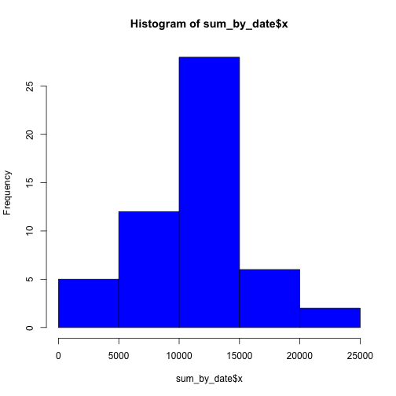

```r
sum_by_date <- aggregate(clean_data$steps, by=list(date=clean_data$date), FUN=sum)
hist(sum_by_date$x, col="blue")
```

this is the Mean by date:

```r
mean_by_date <- aggregate(clean_data$steps, by=list(date=clean_data$date), FUN=mean)
mean_by_date
```

```
##          date       x
## 1  2012-10-02  0.4375
## 2  2012-10-03 39.4167
## 3  2012-10-04 42.0694
## 4  2012-10-05 46.1597
## 5  2012-10-06 53.5417
## 6  2012-10-07 38.2465
## 7  2012-10-09 44.4826
## 8  2012-10-10 34.3750
## 9  2012-10-11 35.7778
## 10 2012-10-12 60.3542
## 11 2012-10-13 43.1458
## 12 2012-10-14 52.4236
## 13 2012-10-15 35.2049
## 14 2012-10-16 52.3750
```

[output cut: 39 more lines]

And this is the Median by Date:

```r
median_by_date <- aggregate(clean_data$steps, by=list(date=clean_data$date), FUN=median)
median_by_date
```

```
##          date x
## 1  2012-10-02 0
## 2  2012-10-03 0
## 3  2012-10-04 0
## 4  2012-10-05 0
## 5  2012-10-06 0
## 6  2012-10-07 0
## 7  2012-10-09 0
## 8  2012-10-10 0
## 9  2012-10-11 0
## 10 2012-10-12 0
## 11 2012-10-13 0
## 12 2012-10-14 0
## 13 2012-10-15 0
## 14 2012-10-16 0
```

[output cut: 39 more lines]

## What is the average daily activity pattern?

We will create mean for the steps per interval and plot the graph:

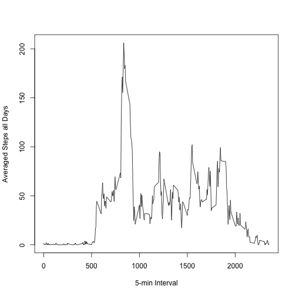

```r
mean_by_interval <- aggregate(clean_data$steps, by=list(interval=clean_data$interval), FUN=mean)
plot(mean_by_interval$interval,mean_by_interval$x,type = "l",xlab="5-min Interval",ylab="Averaged Steps all Days")
```

The time interval that has the maximum number of steps all over the time interval is calculated like this:

```r
max_interval <- mean_by_interval[mean_by_interval$x == max(mean_by_interval$x),]
```

Hence the The interval is: **835**

## Imputing missing values

1. Since I already got the clean data without NA, I just need to calculate the diffirence between the number of rows as follows:

```r
nrow(data)- nrow(clean_data)
```

```
## [1] 2304
```

1. To fill the data set, I will fill the NA data with the mean for that time interval.

```r
na_data = data[is.na(data),]
for(i in 1:nrow(na_data))
{
        na_data[i,"steps"] = mean_by_interval[mean_by_interval$interval == na_data[i,"interval"],]$x
}
```

After filling the na_data, we will be having 2 data frames na data frame and non-na data frame (which we called it clean_data)

1. To create the new data set, we will be appending na_data to clean_data using the below code:

```r
new_data <- rbind(na_data, clean_data)
head(new_data)
```

```
##     steps       date interval
## 1 1.71698 2012-10-01        0
## 2 0.33962 2012-10-01        5
## 3 0.13208 2012-10-01       10
## 4 0.15094 2012-10-01       15
## 5 0.07547 2012-10-01       20
## 6 2.09434 2012-10-01       25
```

1. Lets check out the new data how it will look like and how it will differ in terms of mean and median:

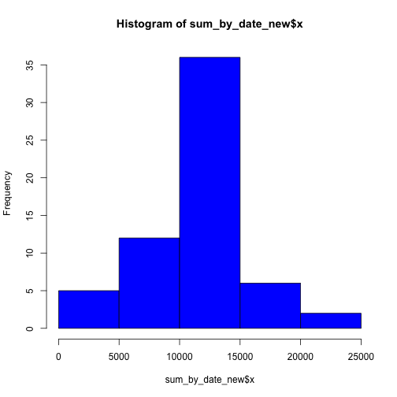

```r
sum_by_date_new <- aggregate(new_data$steps, by=list(date=new_data$date), FUN=sum)
hist(sum_by_date_new$x, col="blue")
```

this is the Mean by date:

```r
mean_by_date_new <- aggregate(new_data$steps, by=list(date=new_data$date), FUN=mean)
mean_by_date_new
```

```
##          date       x
## 1  2012-10-01 37.3826
## 2  2012-10-02  0.4375
## 3  2012-10-03 39.4167
## 4  2012-10-04 42.0694
## 5  2012-10-05 46.1597
## 6  2012-10-06 53.5417
## 7  2012-10-07 38.2465
## 8  2012-10-08 37.3826
## 9  2012-10-09 44.4826
## 10 2012-10-10 34.3750
## 11 2012-10-11 35.7778
## 12 2012-10-12 60.3542
## 13 2012-10-13 43.1458
## 14 2012-10-14 52.4236
```

[output cut: 47 more lines]

And this is the Median by Date:

```r
median_by_date_new <- aggregate(new_data$steps, by=list(date=new_data$date), FUN=median)
median_by_date_new
```

```
##          date     x
## 1  2012-10-01 34.11
## 2  2012-10-02  0.00
## 3  2012-10-03  0.00
## 4  2012-10-04  0.00
## 5  2012-10-05  0.00
## 6  2012-10-06  0.00
## 7  2012-10-07  0.00
## 8  2012-10-08 34.11
## 9  2012-10-09  0.00
## 10 2012-10-10  0.00
## 11 2012-10-11  0.00
## 12 2012-10-12  0.00
## 13 2012-10-13  0.00
## 14 2012-10-14  0.00
```

[output cut: 47 more lines]

## Are there differences in activity patterns between weekdays and weekends?

1. We will create a new valiable called day_type which has weekend or weekday values:

```r
for(i in 1:nrow(new_data))
{
        if(!(weekdays(as.Date(new_data[i,]$date)) %in% c('Saturday','Sunday')))
        {
                type <- "weekday"
        }
        else
        {
                type <- "weekend"
        }
        new_data[i,"day_type"] = type
}
```

1. We need to group the new_data by day_type and interval and then plot the result:

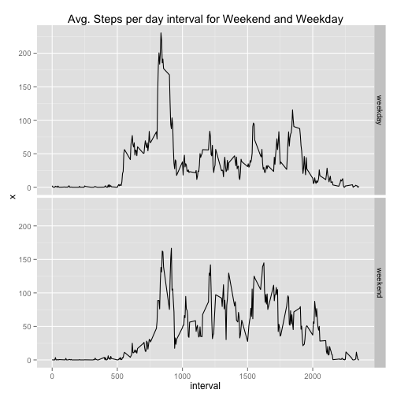

```r
mean_by_day_type_interval <- aggregate(new_data$steps, by=list(interval=new_data$interval,day_type=new_data$day_type), FUN=mean)

library(ggplot2)
g <- ggplot(mean_by_day_type_interval, aes(interval,  x))
g + geom_line() +  facet_grid(day_type ~ .) + ggtitle("Avg. Steps per day interval for Weekend and Weekday")
```